# Lesson 7 R Activity 2

Rick Davila

5/10/2020

## Lesson 7, Windmill Example - Install packages

#### Install necessary packages using library()

#### Perform data housekeeping - upload, name columns, display to make sure it reads properly, etc.

```r
knitr::opts_chunk$set(echo = TRUE)

library(e1071)
library(xtable)
library("xlsx") # Needed to read data
library(psych) # For geometric mean in Example 5.3
rm(list = ls())
```

#### Read data file (data-ex-5-2.xlsx)

```r
ex5_2 <- read.xlsx("data-ex-5-2.xlsx",
                   sheetIndex = 1,
                   colIndex = c(2,3),
                   as.data.frame = TRUE,
                   header = TRUE)
```

#### Assign labels to data columns using names() and attach() commands

```r
names(ex5_2) <- c("Wind_Velocity", "DC_Output")
attach(ex5_2)
```

#### Output data to make sure it reads properly

```r
out <- as.data.frame(c(ex5_2))
colnames(out) <- c("Wing_Velocity", "DC_Output")
tab <- (xtable(out, digits=c(0,2,3)))
print(tab, type="html")
```

|  | Wing_Velocity | DC_Output |
| --- | --- | --- |
| 1 | 5.00 | 1.582 |
| 2 | 6.00 | 1.822 |
| 3 | 3.40 | 1.057 |
| 4 | 2.70 | 0.500 |
| 5 | 10.00 | 2.236 |
| 6 | 9.70 | 2.386 |
| 7 | 9.55 | 2.294 |
| 8 | 3.05 | 0.558 |
| 9 | 8.15 | 2.166 |
| 10 | 6.20 | 1.866 |
| 11 | 2.90 | 0.653 |
| 12 | 6.35 | 1.930 |
| 13 | 4.60 | 1.562 |
| 14 | 5.80 | 1.737 |
| 15 | 7.40 | 2.088 |
| 16 | 3.60 | 1.137 |
| 17 | 7.85 | 2.179 |
| 18 | 8.80 | 2.112 |
| 19 | 7.00 | 1.800 |
| 20 | 5.45 | 1.501 |
| 21 | 9.10 | 2.303 |
| 22 | 10.20 | 2.310 |
| 23 | 4.10 | 1.194 |
| 24 | 3.95 | 1.144 |
| 25 | 2.45 | 0.123 |

```r
# Output data structure and dimensions
str(ex5_2)
```

‘data.frame’: 25 obs. of 2 variables: $ Wind_Velocity: num 5 6 3.4 2.7 10 9.7 9.55 3.05 8.15 6.2 … $ DC_Output : num 1.58 1.82 1.06 0.5 2.24 …

```r
dim(ex5_2)
```

[1] 25 2

## Example 5.2 (p. 178-181)

#### Create scatterplot to visualize data

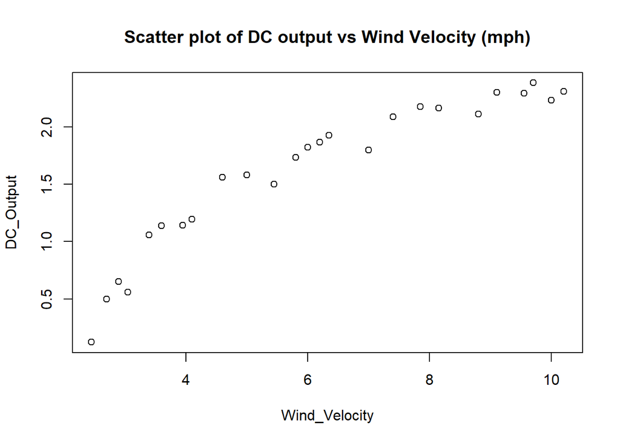

```r
plot(Wind_Velocity,DC_Output, main = "Scatter plot of DC output vs Wind Velocity (mph)")
```

#### Fit linear model first; compare results to p. 178

```r
# Obtain regression estimates using lm command
model <- lm(DC_Output ~ Wind_Velocity)
beta_0 <- model$coefficients[1]
beta_1 <- model$coefficients[2]

# show beta estimates, std. error, tvalues and p-values
xtable(model)
```

|  | Estimate | Std. Error | t value | Pr(>\|t\|) |
| --- | --- | --- | --- | --- |
| (Intercept) | 0.1308751 | 0.1259894 | 1.038779 | 3.097053e-01 |
| Wind_Velocity | 0.2411489 | 0.0190492 | 12.659268 | 7.545525e-12 |

```r
xtable(summary(aov(model)))
```

|  | Df | Sum Sq | Mean Sq | F value | Pr(>F) |
| --- | --- | --- | --- | --- | --- |
| Wind_Velocity | 1 | 8.929615 | 8.92961484 | 160.2571 | 7.545525e-12 |
| Residuals | 23 | 1.281573 | 0.05572057 | NA | NA |

The equation for the linear regression model:
$$\hat{y} = (0.1308751) + (0.2411489)x$$

```r
# ANOVA table
# summary(aov)
out <- anova(model)

xtable(out)
```

|  | Df | Sum Sq | Mean Sq | F value | Pr(>F) |
| --- | --- | --- | --- | --- | --- |
| Wind_Velocity | 1 | 8.929615 | 8.92961484 | 160.2571 | 7.545525e-12 |
| Residuals | 23 | 1.281573 | 0.05572057 | NA | NA |

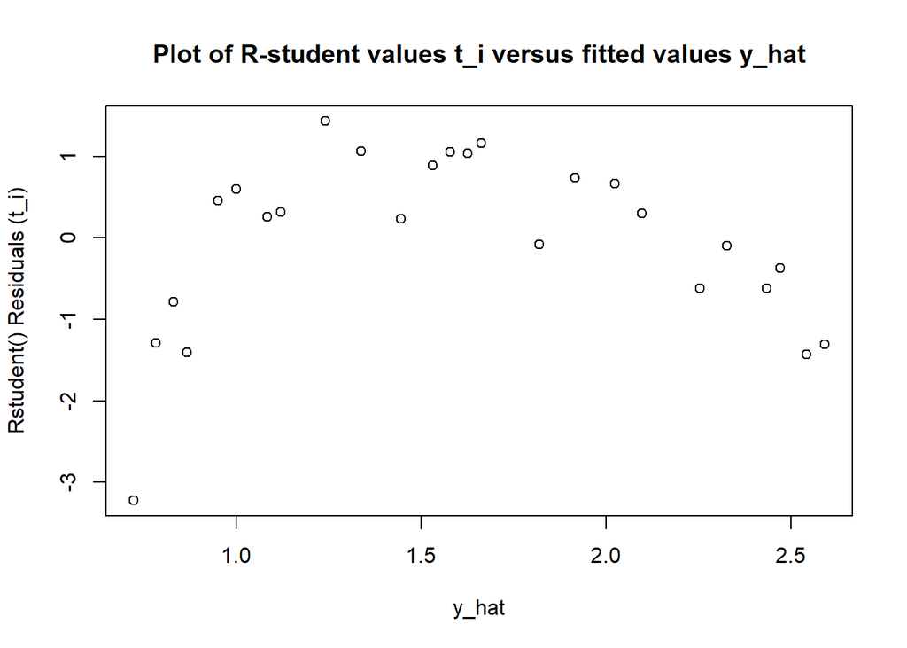

```r
# DC_Output, given Wind_Velocity
model <- lm(DC_Output ~ Wind_Velocity)
beta_0 <- model$coefficients[1]
beta_1 <- model$coefficients[2]

# Calculate y_hat
y_hat <- beta_0 + beta_1*Wind_Velocity

# Calculate R-Student residuals
residuals <- rstudent(model)

plot(y_hat, residuals, main='Plot of R-student values t_i versus fitted values y_hat', xlab = 'y_hat', ylab = 'Rstudent() Residuals (t_i)')
```

#### Residual plots show clear nonlinearity. Attempt to rectify through transformation: x’ = 1/x

```r
Wind_Velocity_t <- 1/Wind_Velocity
```

#### Create scatterplot and model using transformed data; compare to p. 180 and 181

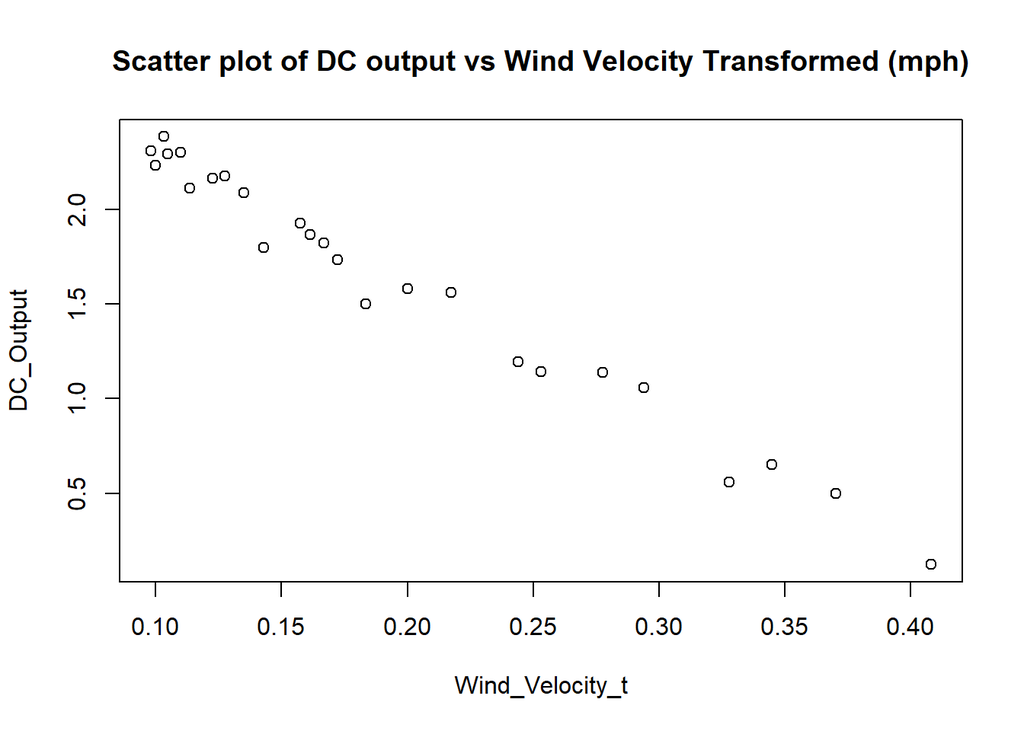

```r
plot(Wind_Velocity_t,DC_Output, main = "Scatter plot of DC output vs Wind Velocity Transformed (mph)")
```

```r
# create lm() model with transformed wind velocity
model_t <- lm(DC_Output ~ Wind_Velocity_t)

#
xtable(model_t)
```

|  | Estimate | Std. Error | t value | Pr(>\|t\|) |
| --- | --- | --- | --- | --- |
| (Intercept) | 2.978860 | 0.04490227 | 66.34096 | 8.917745e-28 |
| Wind_Velocity_t | -6.934547 | 0.20643355 | -33.59215 | 4.742548e-21 |

```r
xtable(summary(aov(model_t)))
```

|  | Df | Sum Sq | Mean Sq | F value | Pr(>F) |
| --- | --- | --- | --- | --- | --- |
| Wind_Velocity_t | 1 | 10.0072184 | 10.007218353 | 1128.433 | 4.742548e-21 |
| Residuals | 23 | 0.2039696 | 0.008868246 | NA | NA |

#### Plot residuals versus fitted values; compare to p. 182

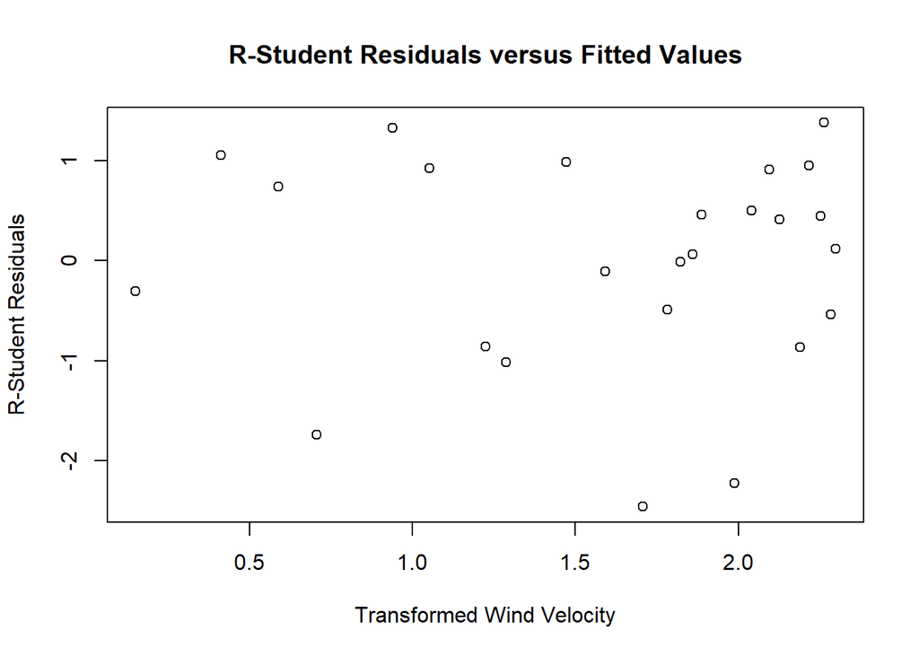

```r
# Calculate r_student residuals
R_Student_Residuals_t <- rstudent(model_t)

y_hat_t <- model_t$fitted.values

plot(y_hat_t, R_Student_Residuals_t, ylab = "R-Student Residuals", xlab = "Transformed Wind Velocity", main = "R−Student Residuals versus Fitted Values")
```

## Example 5.4 (p. 187)

#### Determine alpha value to transform independent variable using Box-Tidwell Procedure

```r
# Obtain regression estimates using lm command, for alpha_0 = 0
model <- lm(DC_Output ~ Wind_Velocity)
beta_0 <- model$coefficients[1]
beta_1 <- model$coefficients[2]

# show beta estimates, std. error, tvalues and p-values
xtable(model)
```

|  | Estimate | Std. Error | t value | Pr(>\|t\|) |
| --- | --- | --- | --- | --- |
| (Intercept) | 0.1308751 | 0.1259894 | 1.038779 | 3.097053e-01 |
| Wind_Velocity | 0.2411489 | 0.0190492 | 12.659268 | 7.545525e-12 |

```r
xtable(summary(aov(model)))
```

|  | Df | Sum Sq | Mean Sq | F value | Pr(>F) |
| --- | --- | --- | --- | --- | --- |
| Wind_Velocity | 1 | 8.929615 | 8.92961484 | 160.2571 | 7.545525e-12 |
| Residuals | 23 | 1.281573 | 0.05572057 | NA | NA |

For step 1.0 we have, the equation for the linear regression model is:

$$\hat{y} = \hat{\beta_0}+\hat{\beta_1}x = (0.1308751) + (0.2411489)x$$

#### Step 1.1: Define 2 = x ln x and add to model as an independent variable; compare output to p. 187

```r
# Then defining w = x ln x, we fit Eq. (5.8) and obtain
w <- Wind_Velocity*log(Wind_Velocity)           #  w = xlog(x)
model <- lm(DC_Output ~ Wind_Velocity + w)
beta_0_star <- model$coefficients[1]
beta_1_star <- model$coefficients[2]
gamma_1 <- model$coefficients[3]

# show beta estimates, std. error, tvalues and  p-values
xtable(model)
```

|  | Estimate | Std. Error | t value | Pr(>\|t\|) |
| --- | --- | --- | --- | --- |
| (Intercept) | -2.4168438 | 0.28511523 | -8.476726 | 2.228595e-08 |
| Wind_Velocity | 1.5344349 | 0.14189388 | 10.813961 | 2.853452e-10 |
| w | -0.4625963 | 0.05065422 | -9.132435 | 6.127920e-09 |

```r
xtable(summary(aov(model)))
```

|  | Df | Sum Sq | Mean Sq | F value | Pr(>F) |
| --- | --- | --- | --- | --- | --- |
| Wind_Velocity | 1 | 8.9296148 | 8.92961484 | 734.40491 | 2.147909e-18 |
| w | 1 | 1.0140756 | 1.01407560 | 83.40137 | 6.127920e-09 |
| Residuals | 22 | 0.2674976 | 0.01215898 | NA | NA |

For step 1.1 we have, the equation for the linear regression model is:
$$\hat{y} =\hat{\beta_0}^* +\hat{\beta_1}^*x + \hat{\gamma}w= (-2.4168438) + (1.5344349)x + (-0.4625963)w$$

#### Step 1.2: Using Equation 5.10, calculate alpha_1; compare to p. 187

```r
alpha_1 <- (gamma_1/beta_1) + 1
```

For step 1.2, we have:
$$\alpha_1 = \frac{\hat{\gamma}}{\hat{\beta_1}} + 1=(-0.9183019)$$

```r
# Obtain regression estimates using lm command, for alpha_0 = 1
Wind_Velocity_t1 <- Wind_Velocity^(alpha_1)
model <- lm(DC_Output ~ Wind_Velocity_t1)
beta_0_t <- model$coefficients[1]
beta_1_t <- model$coefficients[2]

# show beta estimates, std. error, tvalues and  p-values
xtable(model)
```

|  | Estimate | Std. Error | t value | Pr(>\|t\|) |
| --- | --- | --- | --- | --- |
| (Intercept) | 3.103860 | 0.04747509 | 65.37871 | 1.245836e-27 |
| Wind_Velocity_t1 | -6.678423 | 0.19538144 | -34.18146 | 3.203122e-21 |

```r
xtable(summary(aov(model)))
```

|  | Df | Sum Sq | Mean Sq | F value | Pr(>F) |
| --- | --- | --- | --- | --- | --- |
| Wind_Velocity_t1 | 1 | 10.0140562 | 10.014056206 | 1168.372 | 3.203122e-21 |
| Residuals | 23 | 0.1971318 | 0.008570948 | NA | NA |

For step 2.0, $x^{\prime}=x^{-0.9183019}$ and the equation for the linear regression model is:
$$\hat{y} = \hat{\beta_0}+\hat{\beta_1}x^{\prime} = (3.10386) + (-6.6784226)x^{\prime}$$

#### Step 2.1: Define w’ = x’ ln x’, add as independent variable, and run model

```r
# Obtain regression estimates using lm command
w_t1 <- Wind_Velocity_t1*log(Wind_Velocity_t1) # w = x'log(x')
model <- lm(DC_Output ~ Wind_Velocity_t1 + w_t1)
beta_0_star_t1 <- model$coefficients[1]
beta_1_star_t1 <- model$coefficients[2]
gamma_1_t1 <- model$coefficients[3]

# show beta estimates, std. error, tvalues and  p-values
xtable(model)
```

|  | Estimate | Std. Error | t value | Pr(>\|t\|) |
| --- | --- | --- | --- | --- |
| (Intercept) | 3.2409424 | 0.2707985 | 11.9680954 | 4.184077e-11 |
| Wind_Velocity_t1 | -6.4444831 | 0.4962074 | -12.9874786 | 8.580514e-12 |
| w_t1 | 0.5994122 | 1.1651551 | 0.5144484 | 6.120681e-01 |

```r
xtable(summary(aov(model)))
```

|  | Df | Sum Sq | Mean Sq | F value | Pr(>F) |
| --- | --- | --- | --- | --- | --- |
| Wind_Velocity_t1 | 1 | 10.014056206 | 10.014056206 | 1131.0176009 | 2.070529e-20 |
| w_t1 | 1 | 0.002343281 | 0.002343281 | 0.2646572 | 6.120681e-01 |
| Residuals | 22 | 0.194788513 | 0.008854023 | NA | NA |

For step 2.1 we have, the equation for the linear regression model is:

$$\hat{y} =\hat{\beta_0}^* +\hat{\beta_1}^*x^{\prime}+\hat{\gamma}w^{\prime} = (3.2409424) + (-6.4444831)x^{\prime} + (0.5994122)w^{\prime}$$

#### Step 2.2: Using equation 5.10, calculate alpha_2; compare to value on p. 187. Pretty close to -1, which was the transformation in Example 5.2.

```r
alpha_2 <- (gamma_1_t1/beta_1_t) + alpha_1
```

$$\alpha_2 = \frac{\hat{\gamma}}{\hat{\beta_1}} + \alpha_1 =(-1.0080555)$$